# Properties of Single Locus

2019-07-04

*This is the notebook for chapter 4 in Genetics and Analysis of Quantitative Traits.*

### Basic definitions

- Gene
- Locus
- Alleles
- Sex Chromosomes
- Autosomes
- Quantitative-trait Loci (QTLs)

### Allele and genotype frequencies

Suppose $P_{11}$, $P_{12}$, and $P_{22}$ represent the proportions of the population that are $B_1B_1$, $B_1B_2$, and $B_2B_2$. The frequency of the $B_1$ allele is

$$p_1=\frac{2P_{11}N+P_{12}N}{2N}=P_{11}+\frac{1}{2}P_{12}$$

### Hardy-Weinberg Principle

- Assumptions
1. no mutation
2. random mating
3. no gene flow
4. infinite population size
5. no selection

Under the conditions of our idealized population, in the next generation and in all subsequent generations, the $B_1B_1$, $B_1B_2$, and $B_2B_2$ genotypes will be found in frequencies $p^2_1$, $2p_1p_2$, and $p^2_2$.

#### Sex-Linked Loci

$$p_1=[p_{1m}(0)+2p_{1f}(0)]/3$$
$$p_{1m}(t)=p_{1f}(t-1)$$
$$p_{1f}(t)=\frac{p_{1f}(t-1)+p_{1m}(t-1)}{2}$$

general solution

$$p_{1f}(t)-p_1=[-\frac{1}{2}]^t[p_{1f}(0)-p_1]$$

A simulation study

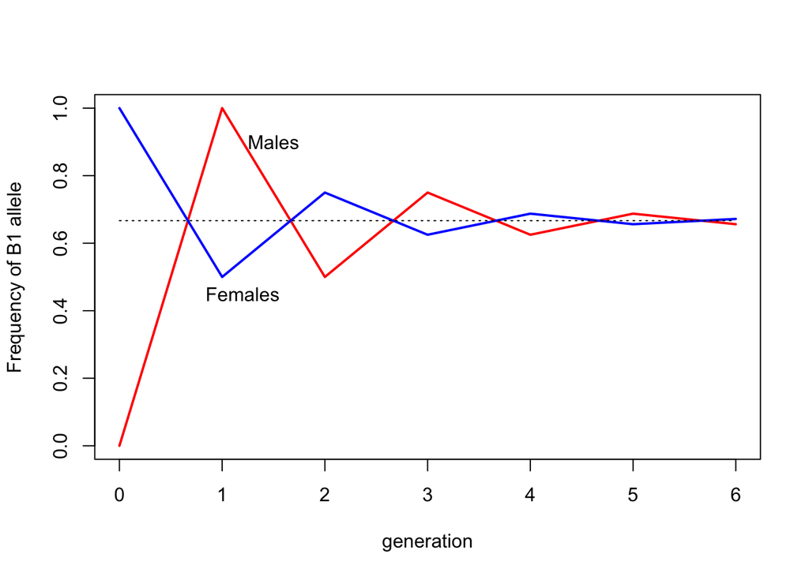

```r
p_1f0 <- 1
p_1m0 <- 0
generation <- 0:6
p_1 <- (p_1m0 + 2*p_1f0) / 3
p_1m <- numeric(length = 7); p_1m[1] <- 0
p_1f <- numeric(length = 7); p_1f[1] <- 1
for (i in 1:6) {
    p_1f[i + 1] <- (-1/2)^i * (p_1f0 - p_1) + p_1
    p_1m[i + 1] <- p_1f[i]
}
plot(generation, p_1m, col = 'red', type = 'l', ylab = 'Frequency of B1 allele', lwd = 2)
lines(generation, p_1f, col = 'blue', lwd = 2)
lines(generation, rep(p_1, 7), col = 'black', lty = 'dotted')
text(1.5, 0.9, labels = "Males")
text(1.2, 0.45, labels = "Females")
```

#### Testing for HWE

- $\chi^2$ test
- likelihood-ratio test

```r
library(HardyWeinberg, quietly = T)
x <- c(MM = 298, MN = 489, NN = 213)
HW.test <- HWChisq(x, verbose = TRUE)
```

```
## Chi-square test with continuity correction for Hardy-Weinberg equilibrium (autosomal)
## Chi2 =  0.1789563 DF =  1 p-value =  0.6722717 D =  -3.69375 f =  0.01488253
```

```r
HW.lrtest <- HWLratio(x, verbose = TRUE)
```

```
## Likelihood ratio test for Hardy-Weinberg equilibrium
## G2 = 0.2214663 DF = 1 p-value = 0.637925
```

### Characterizing the influence of a locus on the phenotype

$$z=G+E$$

Genotypic value: $B_1B_1=0$, $B_1B_2=(1+k)a$, $B_2B_2=2a$

If $k>1$, **overdominance**, $k<-1$, **underdominance**

### Fisher’s decomposition of the genotypic value

The number of copies of a particular allele in a genotype is referred to as the **gene content**.

$$G_{ij}=\hat{G_{ij}}+\delta_{ij}=\mu_G+\alpha_1N_1+\alpha_2N_2+\delta_{ij}$$
$$G_{ij}=\mu_G+\alpha_1(2-N_2)+\alpha_2N_2+\delta_{ij}=\iota+(\alpha_2-\alpha_1)N_2+\delta_{ij}$$

$\iota=\mu_G+2\alpha_1$ is the intercept, the slope is $\alpha=\alpha_2-\alpha_1$.

$$\hat{G_{ij}}=\mu_G+\alpha_i+\alpha_j=\begin{cases}
\mu_G+2\alpha_1, for G_{11}\\
\mu_G+\alpha_1+\alpha_2, for G_{21}\\
\mu_G+2\alpha_2, for G_{22}
\end{cases}$$

$$\mu_G=\mu_G+\alpha_1E(N_1)+\alpha_2E(N_2)+0$$
$$p_1\alpha_1+p_2\alpha_2=0$$
$$p_1+p_2=1$$
we obtain

$\alpha_2=p_1\alpha$ and $\alpha_1=-p_2\alpha$
$$\alpha=\frac{\sigma(G,N_2)}{\sigma^2(N_2)}=a[1+k(p_1-p_2)]$$

- Explore the relationship between gene content and genotypic value with different $p_2$ and $k$

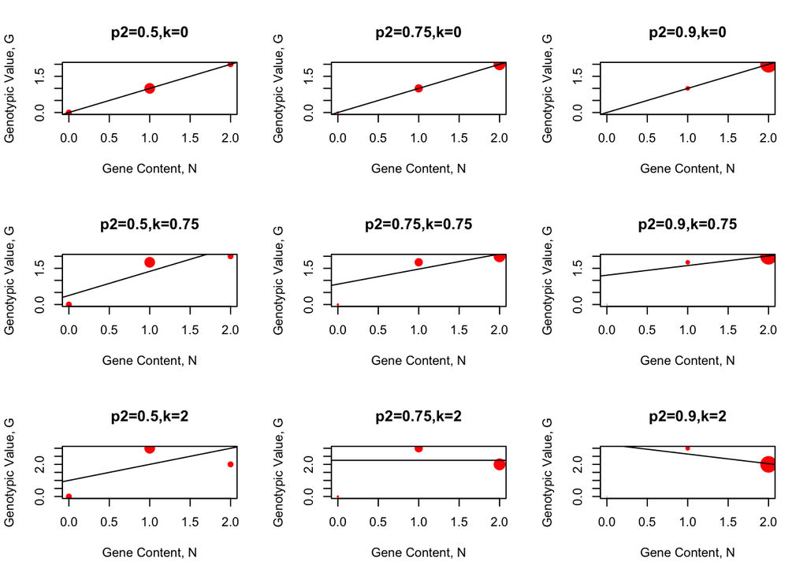

```r
p2 <- rep(c(0.5, 0.75, 0.9), 3)
k <- rep(c(0, 0.75, 2), each = 3)
gc <- c(0, 1, 2)
# suppose a=1
a <- 1
y <- numeric(length = 3)
par(mfrow = c(3, 3))
for (i in 1:9) {
    y[1] <- 0
    y[2] <- a*(1+k[i])
    y[3] <- 2*a
    plot(gc, y, pch = 20, cex = 5*c((1-p2[i])^2, 2*(1-p2[i])*p2[i], p2[i]^2), col='red', xlab = 'Gene Content, N', ylab = 'Genotypic Value, G', main = paste0('p2=', p2[i], ',', 'k=', k[i]))
    alpha <- a*(1+k[i]*(1-2*p2[i]))
    alpha_1 <- -p2[i]*alpha
    iota <- 2*p2[i]*a*(1+(1-p2[i])*k[i])+2*alpha_1
    y_hat <- c(iota, iota+alpha, iota+2*alpha)
    abline(lm(y_hat ~ gc))
}
```

For all cases when $p_2=p_1=0.5$, the slope $\alpha=a$ regardless of the degree of dominance.

Under the assumption of random mating, $\alpha$ is known as the **average effect of allelic substitution**.

### Partitioning the genetic variance

$$G=\hat{G}+\delta$$
$$\sigma^2_G=\sigma^2(\hat{G}+\delta)=\sigma^2(\hat{G})+2\sigma(\hat{G},\delta)+\sigma^2(\delta)$$
$$\sigma^2_G=\sigma^2_A+\sigma^2_D$$
$$\sigma^2_A=E(\hat{G}^2)-\mu^2_\hat{G}=2p_1p_2\alpha^2$$
$$\sigma^2_D=E(\delta^2)-\mu^2_\delta=(2p_1p_2ak)^2$$

- Explore the relationship between $p_2$ and genetic variance with different $k$

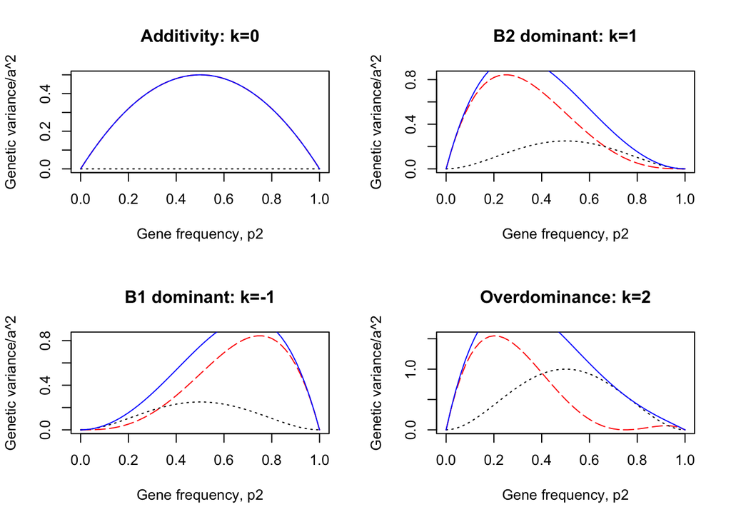

```r
k <- c(0, 1, -1, 2)
p2 <- seq(0, 1, 0.02)
par(mfrow=c(2,2))
t <- c('Additivity: k=0','B2 dominant: k=1','B1 dominant: k=-1', 'Overdominance: k=2')
for (i in 1:4) {
    va <- 2*(1-p2)*p2*(1+k[i]*(1-2*p2))^2
    vd <- (2*(1-p2)*p2*k[i])^2
    v <- va+vd
    plot(p2, va, main = t[i], type = 'l', xlab = 'Gene frequency, p2', ylab = 'Genetic variance/a^2', lty = 'longdash', col='red')
    lines(p2, vd, lty = 'dotted')
    lines(p2, v, col='blue')
}
```

### Additive effects, average excesses, and breeding values

One can think of $\hat G$ and $\delta$ as the heritable and nonheritable components of an individual’s genotypic value.

- Average excess $\alpha_2^*$ of allele $B_2$

$$\alpha^*_2=(G_{12}P_{12|2}+G_{22}P_{22|2})-\mu_G=(G_{12}p_1+G_{22}p_2)-\mu_G$$

Additive effects are identical to average excesses in randomly mating populations.

- Average effects $\alpha_i$
- Breeding value

  The sum of the additive effects of its genes.